# Mid-Term, DSCI 1500, Begin Data Science- Analytics

Neemias Moreira

2023-10-22

### Mid Term - exploratory analysis of GPA

This is an exploratory analysis of a data set GPA, from a survey from Duke University where 55 students asked about their GPA, number of hours they study at night, number of nights they go out, and their gender.

The final goal of this project it’s to create a model to predict the GPA based in one or more variables.

The first observation before we start the analysis is this data sample is small for the population being observed. So, my first recommendation is about increasing the number of students being asked to at least 100, to have a better analysis and with a higher confidence level.

## Model 1- Linear Model with one explanatory variable

```r
gpa <- read.csv("gpa.csv")

summary(gpa)
```

```
##       gpa          studyweek       sleepnight         out
##  Min.   :2.900   Min.   : 2.00   Min.   :5.000   Min.   :0.000
##  1st Qu.:3.400   1st Qu.:10.00   1st Qu.:6.000   1st Qu.:1.250
##  Median :3.650   Median :15.00   Median :7.000   Median :2.000
##  Mean   :3.600   Mean   :19.15   Mean   :7.064   Mean   :2.109
##  3rd Qu.:3.825   3rd Qu.:26.50   3rd Qu.:8.000   3rd Qu.:3.000
##  Max.   :4.670   Max.   :50.00   Max.   :9.000   Max.   :4.000
##     gender
##  Length:55
##  Class :character
##  Mode  :character
##
##
##
```

As you can see we have an outlier on this data set on the GPA row, showing an GPA of 4.670. So we will filter this data to have only GPA’s between 0.0 - 4.0.

```
##       gpa          studyweek       sleepnight         out
##  Min.   :2.900   Min.   : 2.00   Min.   :5.000   Min.   :0.000
##  1st Qu.:3.400   1st Qu.:10.00   1st Qu.:6.000   1st Qu.:1.125
##  Median :3.625   Median :15.00   Median :7.000   Median :2.000
##  Mean   :3.580   Mean   :19.24   Mean   :7.074   Mean   :2.093
##  3rd Qu.:3.821   3rd Qu.:27.25   3rd Qu.:8.000   3rd Qu.:3.000
##  Max.   :4.000   Max.   :50.00   Max.   :9.000   Max.   :4.000
##     gender
##  Length:54
##  Class :character
##  Mode  :character
##
##
##
```

Now we’re going to start the exploratory analysis, with one variable hours of sleep at night.

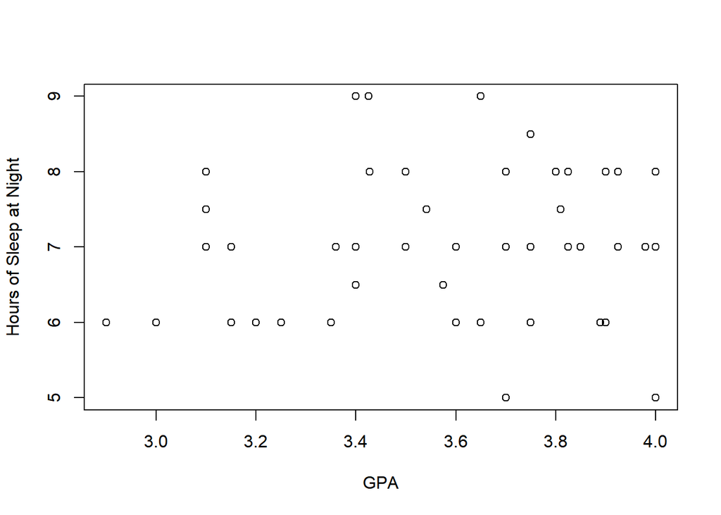

```r
plot(gpa4$gpa, xlab="GPA", gpa4$sleepnight, ylab = "Hours of Sleep at Night")
```

```r
lineargpa <- lm(gpa ~ sleepnight  , gpa4)
summary(lineargpa)
```

```
##
## Call:
## lm(formula = gpa ~ sleepnight, data = gpa4)
##
## Residuals:
##      Min       1Q   Median       3Q      Max
## -0.64731 -0.21009  0.05269  0.21659  0.48337
##
## Coefficients:
##             Estimate Std. Error t value Pr(>|t|)
## (Intercept)  3.36323    0.28903  11.636  4.3e-16 ***
## sleepnight   0.03068    0.04043   0.759    0.451
## ---
## Signif. codes:  0 '***' 0.001 '**' 0.01 '*' 0.05 '.' 0.1 ' ' 1
##
## Residual standard error: 0.3058 on 52 degrees of freedom
## Multiple R-squared:  0.01095,    Adjusted R-squared:  -0.008069
## F-statistic: 0.5757 on 1 and 52 DF,  p-value: 0.4514
```

Now, the linear equation has the form:
$$y = \beta_0 + \beta_1X_1$$
The equation predicted by the model is:
$$GPA = 3.36323 + 0.03068(\frac{GPA}{Sleep Night})Sleep Night$$

#Let’s start test our model and try to predict some values. First, using the Train Test Approach we have those followings results:

```
##
## Call:
## lm(formula = gpa ~ sleepnight, data = Train)
##
## Residuals:
##      Min       1Q   Median       3Q      Max
## -0.63201 -0.18959  0.05385  0.19920  0.38213
##
## Coefficients:
##             Estimate Std. Error t value Pr(>|t|)
## (Intercept)  3.71684    0.30292  12.270 3.11e-14 ***
## sleepnight  -0.01414    0.04250  -0.333    0.741
## ---
## Signif. codes:  0 '***' 0.001 '**' 0.01 '*' 0.05 '.' 0.1 ' ' 1
##
## Residual standard error: 0.2873 on 35 degrees of freedom
## Multiple R-squared:  0.003152,   Adjusted R-squared:  -0.02533
## F-statistic: 0.1107 on 1 and 35 DF,  p-value: 0.7414
```

#Now doing the prediction on the train test:

```r
predict(gpalmTT, Test)
```

```
##        1        9       11       12       19       22       24       26
## 3.632008 3.603733 3.603733 3.632008 3.624939 3.603733 3.603733 3.603733
##       29       30       32       36       38       45       49       53
## 3.632008 3.624939 3.617870 3.617870 3.603733 3.617870 3.603733 3.610802
##       54
## 3.632008
```

```r
predGpa <- predict(gpalmTT, Test)
actGpa <- Test$gpa
Outcome <- data.frame(cbind(actGpa, predGpa))

Outcome <- mutate(Outcome, percentdiff = (actGpa - predGpa)/actGpa*100)
Outcome
```

```
##    actGpa  predGpa percentdiff
## 1   3.890 3.632008    6.632178
## 9   3.428 3.603733   -5.126389
## 11  3.900 3.603733    7.596599
## 12  2.900 3.632008  -25.241665
## 19  3.575 3.624939   -1.396905
## 22  3.500 3.603733   -2.963789
## 24  3.825 3.603733    5.784768
## 26  4.000 3.603733    9.906684
## 29  3.150 3.632008  -15.301850
## 30  3.400 3.624939   -6.615864
## 32  3.360 3.617870   -7.674716
## 36  3.825 3.617870    5.415152
## 38  3.500 3.603733   -2.963789
## 45  3.100 3.617870  -16.705498
## 49  3.700 3.603733    2.601821
## 53  3.541 3.610802   -1.971238
## 54  2.900 3.632008  -25.241665
```

And the mean and the median of this test is:

```r
mean(Outcome$percentdiff)
```

```
## [1] -4.309775
```

```r
median(Outcome$percentdiff)
```

```
## [1] -2.963789
```

Second, let’s predict the GPA with two values of sleep at night that we don’t have on the data set. And will be 3 and 10 hours of sleep.

```r
df <-data.frame(sleepnight = c(3, 10))
predict(lineargpa, df)
```

```
##        1        2
## 3.455270 3.670024
```

```r
pred <- predict(lineargpa,df, interval= "confidence", level=0.95)
pred
```

```
##        fit      lwr      upr
## 1 3.455270 3.114343 3.796197
## 2 3.670024 3.418376 3.921673
```

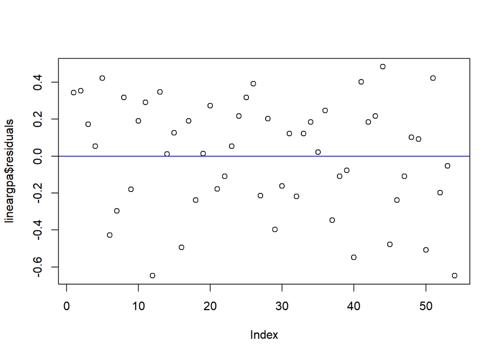

```r
plot(lineargpa$residuals)
abline(h=0, col="blue")
```

As show above the prediction was a good prediction. However, needs to be mention that any of the statistic values can support this model. For instance the R-Value is 0.003152 which is really low. Also, the F- Value and the P- Value are not significant and we cannot reject the Null hypothesis.

## Model 2. – Linear Smoothing with one explanatory variable

Now, we are going to see this model in a GGPlot to have a better visualization of this model.

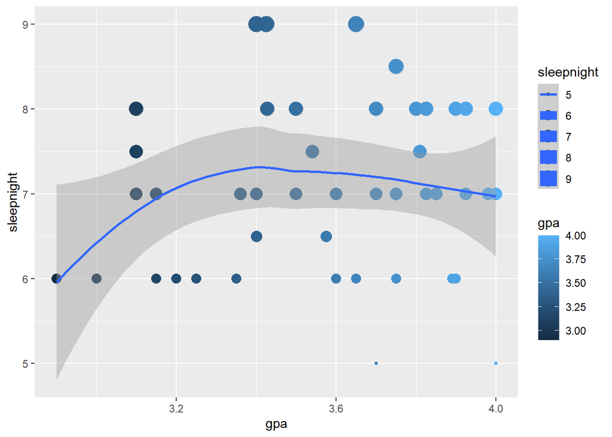

## Model 3 – A polynomial model with on explanatory variable

```r
gpa4_M3 <- mutate(gpa4, sq = sleepnight^2)
str(gpa4_M3)
```

```
## 'data.frame':    54 obs. of  6 variables:
##  $ gpa       : num  3.89 3.9 3.75 3.6 4 ...
##  $ studyweek : int  50 15 15 10 25 20 15 10 12 2 ...
##  $ sleepnight: num  6 6 7 6 7 7 6 8 8 8 ...
##  $ out       : num  3 1 1 4 3 3 1 3 2 4 ...
##  $ gender    : chr  "female" "female" "female" "male" ...
##  $ sq        : num  36 36 49 36 49 49 36 64 64 64 ...
```

```r
gpa4_M3sq <- lm (gpa ~ sleepnight + sq, gpa4_M3)
```

Let’s plot this value on a GG Plot to a better visualization of this model:

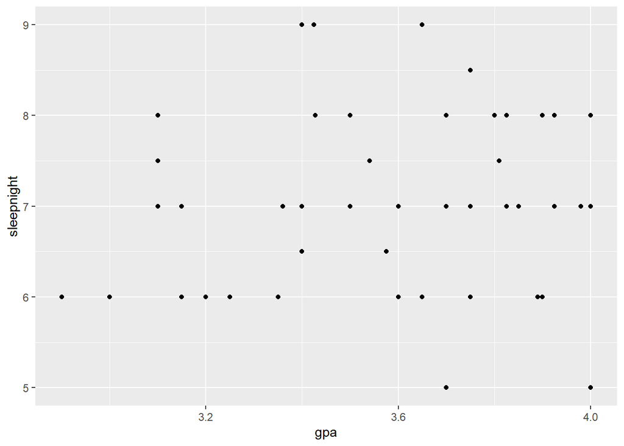

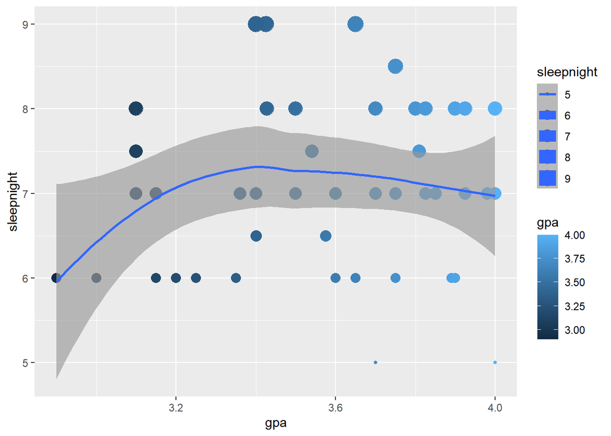

Now, the train test:

```
##
## Call:
## lm(formula = gpa ~ sleepnight, data = Train3)
##
## Residuals:
##      Min       1Q   Median       3Q      Max
## -0.63201 -0.18959  0.05385  0.19920  0.38213
##
## Coefficients:
##             Estimate Std. Error t value Pr(>|t|)
## (Intercept)  3.71684    0.30292  12.270 3.11e-14 ***
## sleepnight  -0.01414    0.04250  -0.333    0.741
## ---
## Signif. codes:  0 '***' 0.001 '**' 0.01 '*' 0.05 '.' 0.1 ' ' 1
##
## Residual standard error: 0.2873 on 35 degrees of freedom
## Multiple R-squared:  0.003152,   Adjusted R-squared:  -0.02533
## F-statistic: 0.1107 on 1 and 35 DF,  p-value: 0.7414
```

```
##        1        9       11       12       19       22       24       26
## 3.632008 3.603733 3.603733 3.632008 3.624939 3.603733 3.603733 3.603733
##       29       30       32       36       38       45       49       53
## 3.632008 3.624939 3.617870 3.617870 3.603733 3.617870 3.603733 3.610802
##       54
## 3.632008
```

```
##    actGpa3 predGpa3 percentdiff
## 1    3.890 3.632008    6.632178
## 9    3.428 3.603733   -5.126389
## 11   3.900 3.603733    7.596599
## 12   2.900 3.632008  -25.241665
## 19   3.575 3.624939   -1.396905
## 22   3.500 3.603733   -2.963789
## 24   3.825 3.603733    5.784768
## 26   4.000 3.603733    9.906684
## 29   3.150 3.632008  -15.301850
## 30   3.400 3.624939   -6.615864
## 32   3.360 3.617870   -7.674716
## 36   3.825 3.617870    5.415152
## 38   3.500 3.603733   -2.963789
## 45   3.100 3.617870  -16.705498
## 49   3.700 3.603733    2.601821
## 53   3.541 3.610802   -1.971238
## 54   2.900 3.632008  -25.241665
```

Mean:

```
## [1] -4.309775
```

Median:

```
## [1] -2.963789
```

Now the GGplot of this model:

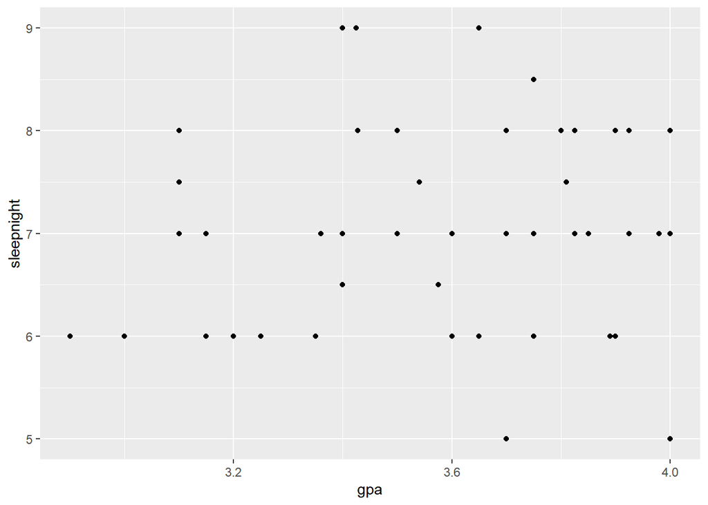

```r
ggplot(gpa4_M3, aes(x=gpa, y=sleepnight))+
  geom_point()
```

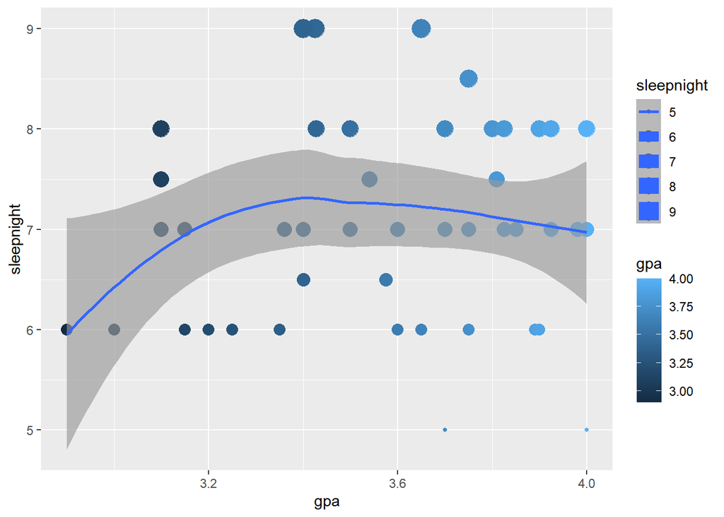

```r
plotgpa + geom_smooth(span=1)
```

## Model 4 - Linear Multivariable Model with one quantitative explanatory variable and one qualitative explanatory variable

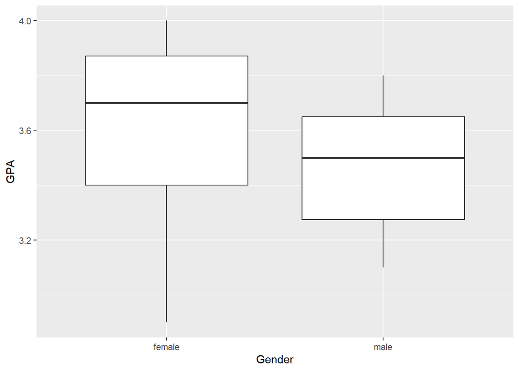

```r
plot(ggplot(gpa4, aes(x= gender, y=gpa))+ geom_boxplot()+labs(x ="Gender", y= "GPA")
)
```

```r
lineargpa4 <- lm(gpa ~ sleepnight + gender  , gpa4)
summary(lineargpa4)
```

```
##
## Call:
## lm(formula = gpa ~ sleepnight + gender, data = gpa4)
##
## Residuals:
##      Min       1Q   Median       3Q      Max
## -0.67244 -0.22212  0.03919  0.24791  0.46594
##
## Coefficients:
##             Estimate Std. Error t value Pr(>|t|)
## (Intercept)  3.34219    0.28511  11.723 4.36e-16 ***
## sleepnight   0.03837    0.04013   0.956    0.343
## gendermale  -0.16393    0.10255  -1.598    0.116
## ---
## Signif. codes:  0 '***' 0.001 '**' 0.01 '*' 0.05 '.' 0.1 ' ' 1
##
## Residual standard error: 0.3013 on 51 degrees of freedom
## Multiple R-squared:  0.05814,    Adjusted R-squared:  0.0212
## F-statistic: 1.574 on 2 and 51 DF,  p-value: 0.2171
```

Let’s go on and do more analysis on this model.

Now, the linear equation has the form:
$$y = \beta_0 + \beta_1X_1 + \beta_2X_2$$
The equation predicted by the model is:
$$GPA = 3.34219(GPA) + 0.03837(SleepNight) - 0.16393 (Gender)$$
Let’s start test our model and try to predict some values. First, using the Train Test Approach we have those followings results:

```
##
## Call:
## lm(formula = gpa ~ sleepnight + gender, data = Train4)
##
## Residuals:
##      Min       1Q   Median       3Q      Max
## -0.66151 -0.20612  0.04862  0.20435  0.34862
##
## Coefficients:
##             Estimate Std. Error t value Pr(>|t|)
## (Intercept)  3.72229    0.29921  12.440  3.3e-14 ***
## sleepnight  -0.01013    0.04208  -0.241    0.811
## gendermale  -0.15573    0.11358  -1.371    0.179
## ---
## Signif. codes:  0 '***' 0.001 '**' 0.01 '*' 0.05 '.' 0.1 ' ' 1
##
## Residual standard error: 0.2837 on 34 degrees of freedom
## Multiple R-squared:  0.05538,    Adjusted R-squared:  -0.0001844
## F-statistic: 0.9967 on 2 and 34 DF,  p-value: 0.3796
```

```
##        1        9       11       12       19       22       24       26
## 3.661510 3.641249 3.641249 3.661510 3.656445 3.485519 3.641249 3.641249
##       29       30       32       36       38       45       49       53
## 3.661510 3.656445 3.651379 3.651379 3.485519 3.495649 3.641249 3.646314
##       54
## 3.661510
```

```
##    actGpa4 predGpa4 percentdiff
## 1    3.890 3.661510   5.8737816
## 9    3.428 3.641249  -6.2207913
## 11   3.900 3.641249   6.6346480
## 12   2.900 3.661510 -26.2589619
## 19   3.575 3.656445  -2.2781707
## 22   3.500 3.485519   0.4137457
## 24   3.825 3.641249   4.8039549
## 26   4.000 3.641249   8.9687818
## 29   3.150 3.661510 -16.2384094
## 30   3.400 3.656445  -7.5424883
## 32   3.360 3.651379  -8.6720033
## 36   3.825 3.651379   4.5391030
## 38   3.500 3.485519   0.4137457
## 45   3.100 3.495649 -12.7628866
## 49   3.700 3.641249   1.5878723
## 53   3.541 3.646314  -2.9741321
## 54   2.900 3.661510 -26.2589619
```

And the mean of this test is:

```r
mean(Outcome4$percentdiff)
```

```
## [1] -4.468892
```

Median:

```r
median(Outcome4$percentdiff)
```

```
## [1] -2.278171
```

## Model 5 - Linear Multivariate Model with 3 or 4 variables

Furthermore, we’re going to start the exploratory analysis, with 3 variable hours of sleep at night, hours of study at week, hours going out. I choose those because they are all the quantitatives variables on my data set.

```r
lineargpa5 <- lm(gpa ~ sleepnight + out + studyweek  , gpa4)
summary(lineargpa5)
```

```
##
## Call:
## lm(formula = gpa ~ sleepnight + out + studyweek, data = gpa4)
##
## Residuals:
##      Min       1Q   Median       3Q      Max
## -0.67236 -0.21625  0.04272  0.23270  0.44739
##
## Coefficients:
##             Estimate Std. Error t value Pr(>|t|)
## (Intercept) 3.294510   0.317981  10.361 4.81e-14 ***
## sleepnight  0.028952   0.045324   0.639    0.526
## out         0.017475   0.046144   0.379    0.707
## studyweek   0.002306   0.003469   0.665    0.509
## ---
## Signif. codes:  0 '***' 0.001 '**' 0.01 '*' 0.05 '.' 0.1 ' ' 1
##
## Residual standard error: 0.31 on 50 degrees of freedom
## Multiple R-squared:  0.02267,    Adjusted R-squared:  -0.03597
## F-statistic: 0.3866 on 3 and 50 DF,  p-value: 0.7631
```

Now, the linear equation has the form:
$$y = \beta_0 + \beta_1X_1+ \beta_2X_2+ \beta_3X_3$$
The equation predicted by the model is:
$$GPA = 3.294510(GPA) + 0.028952(StudyNight) + 0.017475(Out) +
0.002306(StudyWeek)$$
Let’s try this model on the train test:

```
##
## Call:
## lm(formula = gpa ~ sleepnight + out + studyweek, data = Train5)
##
## Residuals:
##      Min       1Q   Median       3Q      Max
## -0.62357 -0.16483  0.05992  0.21554  0.37469
##
## Coefficients:
##              Estimate Std. Error t value Pr(>|t|)
## (Intercept)  3.750703   0.346887  10.812 2.21e-12 ***
## sleepnight  -0.021516   0.049372  -0.436    0.666
## out          0.014130   0.054330   0.260    0.796
## studyweek   -0.000687   0.004773  -0.144    0.886
## ---
## Signif. codes:  0 '***' 0.001 '**' 0.01 '*' 0.05 '.' 0.1 ' ' 1
##
## Residual standard error: 0.2954 on 33 degrees of freedom
## Multiple R-squared:  0.006381,   Adjusted R-squared:  -0.08395
## F-statistic: 0.07064 on 3 and 33 DF,  p-value: 0.9752
```

```
##        1        9       11       12       19       22       24       26
## 3.629648 3.598593 3.585837 3.629258 3.601130 3.598593 3.611052 3.593487
##       29       30       32       36       38       45       49       53
## 3.616113 3.633615 3.586742 3.608922 3.600357 3.626292 3.602028 3.589920
##       54
## 3.650258
```

```
##    actGpa5 predGpa5 percentdiff
## 1    3.890 3.629648   6.6928646
## 9    3.428 3.598593  -4.9764685
## 11   3.900 3.585837   8.0554507
## 12   2.900 3.629258 -25.1468331
## 19   3.575 3.601130  -0.7309067
## 22   3.500 3.598593  -2.8169526
## 24   3.825 3.611052   5.5934211
## 26   4.000 3.593487  10.1628369
## 29   3.150 3.616113 -14.7972327
## 30   3.400 3.633615  -6.8710279
## 32   3.360 3.586742  -6.7482808
## 36   3.825 3.608922   5.6491020
## 38   3.500 3.600357  -2.8673374
## 45   3.100 3.626292 -16.9771697
## 49   3.700 3.602028   2.6478788
## 53   3.541 3.589920  -1.3815215
## 54   2.900 3.650258 -25.8709799
```

And the mean and the median of this test is:

```
## [1] -4.140186
```

Median:

```
## [1] -2.816953
```

Second, let’s predict the GPA with two values of sleep at night that we don’t have on the data set.

```r
df5 <-data.frame(sleepnight = c(3, 10), out = c(5,3), studyweek= c(2,5))
predict(lineargpa5, df5)
```

```
##        1        2
## 3.473352 3.647988
```

```r
pred5 <- predict(lineargpa5,df5, interval= "confidence", level=0.95)
pred5
```

```
##        fit      lwr      upr
## 1 3.473352 2.900760 4.045945
## 2 3.647988 3.386075 3.909901
```

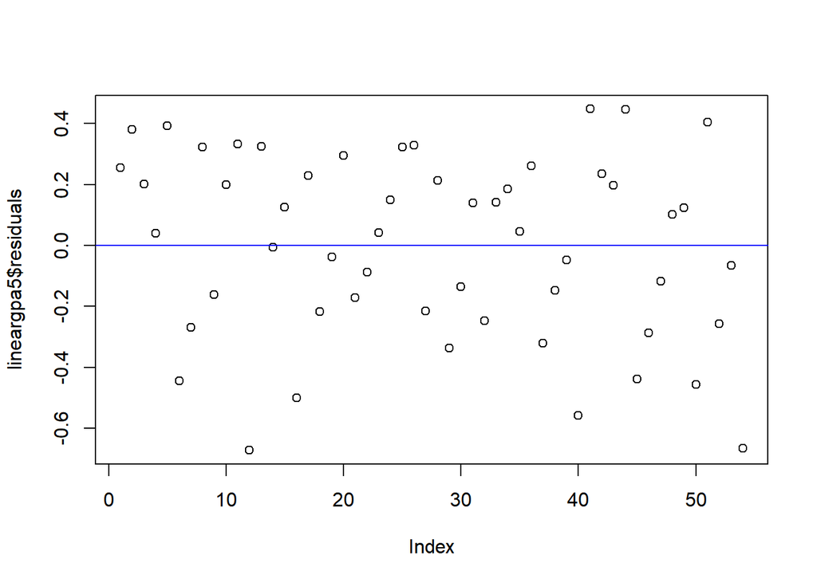

```r
plot(lineargpa5$residuals)
abline(h=0, col="blue")
```

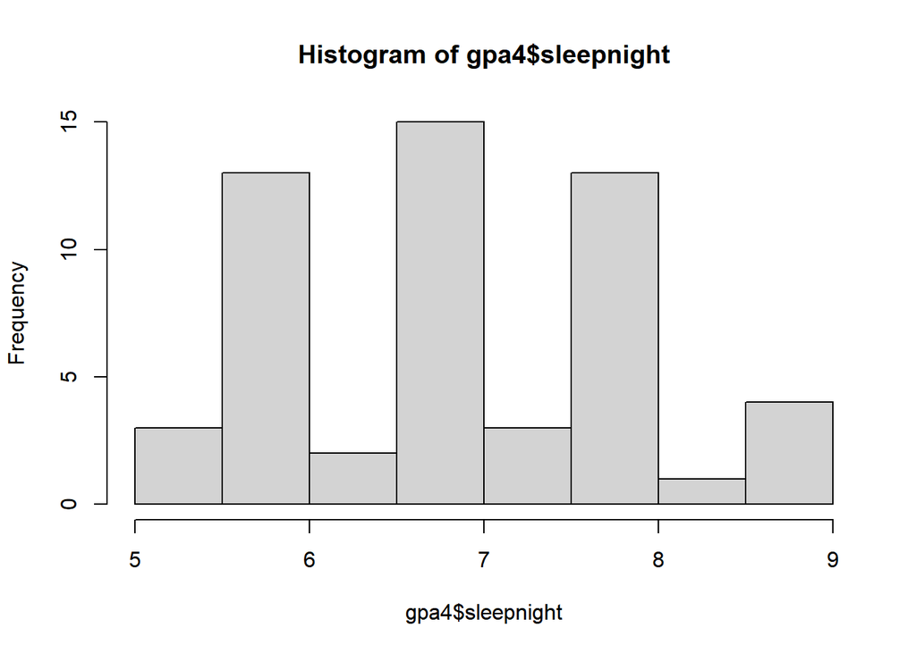

```r
hist(gpa4$sleepnight)
```

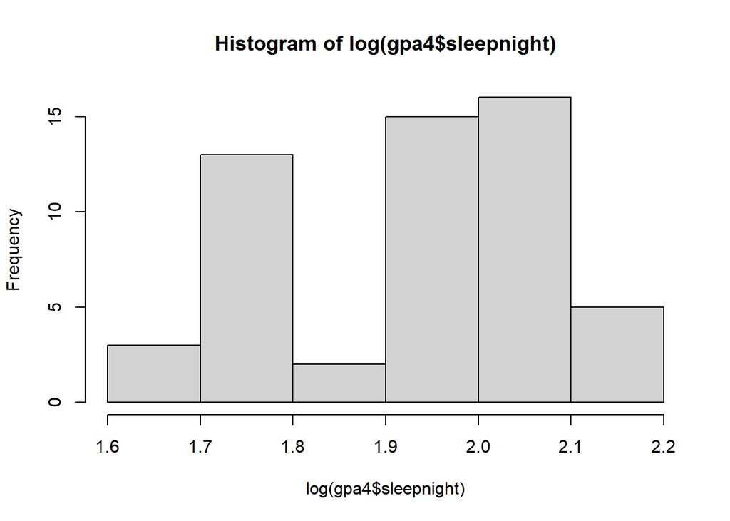

```r
hist(log(gpa4$sleepnight))
```

```r
sleepnightlog <- mutate(gpa4, logp=(sleepnight))
sleepnightlog
```

```
##      gpa studyweek sleepnight out gender logp
## 1  3.890        50        6.0 3.0 female  6.0
## 2  3.900        15        6.0 1.0 female  6.0
## 3  3.750        15        7.0 1.0 female  7.0
## 4  3.600        10        6.0 4.0   male  6.0
## 5  4.000        25        7.0 3.0 female  7.0
## 6  3.150        20        7.0 3.0   male  7.0
## 7  3.250        15        6.0 1.0 female  6.0
## 8  3.925        10        8.0 3.0 female  8.0
## 9  3.428        12        8.0 2.0 female  8.0
## 10 3.800         2        8.0 4.0   male  8.0
## 11 3.900        10        8.0 1.0 female  8.0
## 12 2.900        30        6.0 2.0 female  6.0
## 13 3.925        30        7.0 2.0 female  7.0
## 14 3.650        21        9.0 3.0 female  9.0
```

[output cut: 40 more lines]

```r
lineargpa6_log <- lm(gpa ~ sleepnight  , sleepnightlog)
summary(lineargpa6_log)
```

```
##
## Call:
## lm(formula = gpa ~ sleepnight, data = sleepnightlog)
##
## Residuals:
##      Min       1Q   Median       3Q      Max
## -0.64731 -0.21009  0.05269  0.21659  0.48337
##
## Coefficients:
##             Estimate Std. Error t value Pr(>|t|)
## (Intercept)  3.36323    0.28903  11.636  4.3e-16 ***
## sleepnight   0.03068    0.04043   0.759    0.451
## ---
## Signif. codes:  0 '***' 0.001 '**' 0.01 '*' 0.05 '.' 0.1 ' ' 1
##
## Residual standard error: 0.3058 on 52 degrees of freedom
## Multiple R-squared:  0.01095,    Adjusted R-squared:  -0.008069
## F-statistic: 0.5757 on 1 and 52 DF,  p-value: 0.4514
```

```r
coef(lineargpa6_log)
```

```
## (Intercept)  sleepnight
##  3.36323244  0.03067918
```

And has the following values:

$$GPA = 3.36323(GPA) + 0.03068(SleepNight)$$
Let’s try this model on the train test:

```
##
## Call:
## lm(formula = gpa ~ sleepnight, data = Train6)
##
## Residuals:
##      Min       1Q   Median       3Q      Max
## -0.63201 -0.18959  0.05385  0.19920  0.38213
##
## Coefficients:
##             Estimate Std. Error t value Pr(>|t|)
## (Intercept)  3.71684    0.30292  12.270 3.11e-14 ***
## sleepnight  -0.01414    0.04250  -0.333    0.741
## ---
## Signif. codes:  0 '***' 0.001 '**' 0.01 '*' 0.05 '.' 0.1 ' ' 1
##
## Residual standard error: 0.2873 on 35 degrees of freedom
## Multiple R-squared:  0.003152,   Adjusted R-squared:  -0.02533
## F-statistic: 0.1107 on 1 and 35 DF,  p-value: 0.7414
```

```
##        1        9       11       12       19       22       24       26
## 3.632008 3.603733 3.603733 3.632008 3.624939 3.603733 3.603733 3.603733
##       29       30       32       36       38       45       49       53
## 3.632008 3.624939 3.617870 3.617870 3.603733 3.617870 3.603733 3.610802
##       54
## 3.632008
```

```
##    actGpa6 predGpa6 percentdiff
## 1    3.890 3.632008    6.632178
## 9    3.428 3.603733   -5.126389
## 11   3.900 3.603733    7.596599
## 12   2.900 3.632008  -25.241665
## 19   3.575 3.624939   -1.396905
## 22   3.500 3.603733   -2.963789
## 24   3.825 3.603733    5.784768
## 26   4.000 3.603733    9.906684
## 29   3.150 3.632008  -15.301850
## 30   3.400 3.624939   -6.615864
## 32   3.360 3.617870   -7.674716
## 36   3.825 3.617870    5.415152
## 38   3.500 3.603733   -2.963789
## 45   3.100 3.617870  -16.705498
## 49   3.700 3.603733    2.601821
## 53   3.541 3.610802   -1.971238
## 54   2.900 3.632008  -25.241665
```

Now let’s observe the mean, and median of this model:

```r
mean(Outcome6$percentdiff)
```

```
## [1] -4.309775
```

```r
median(Outcome6$percentdiff)
```

```
## [1] -2.963789
```

Last part of this model will be a prediction of two values:

```
##        1        2
## 3.455270 3.670024
```

```
##        fit      lwr      upr
## 1 3.455270 3.114343 3.796197
## 2 3.670024 3.418376 3.921673
```

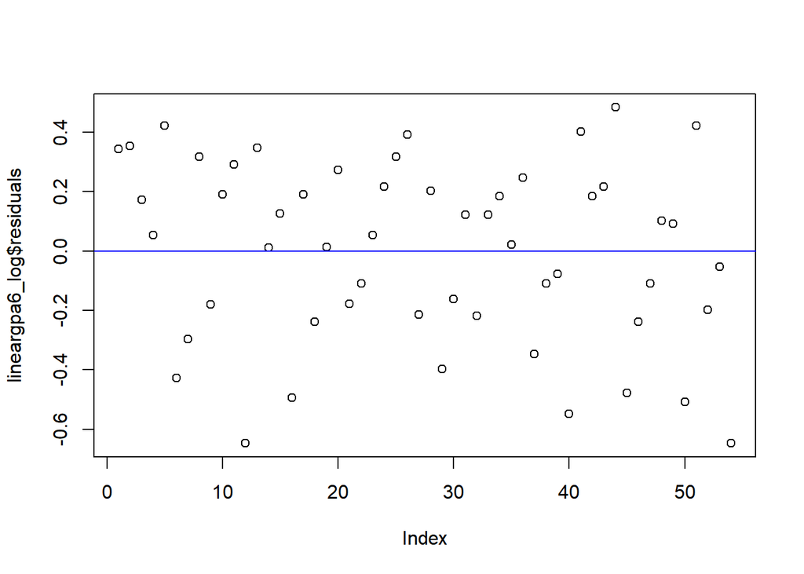

```
##
## Call:
## lm(formula = gpa ~ sleepnight, data = sleepnightlog)
##
## Residuals:
##      Min       1Q   Median       3Q      Max
## -0.64731 -0.21009  0.05269  0.21659  0.48337
##
## Coefficients:
##             Estimate Std. Error t value Pr(>|t|)
## (Intercept)  3.36323    0.28903  11.636  4.3e-16 ***
## sleepnight   0.03068    0.04043   0.759    0.451
## ---
## Signif. codes:  0 '***' 0.001 '**' 0.01 '*' 0.05 '.' 0.1 ' ' 1
##
## Residual standard error: 0.3058 on 52 degrees of freedom
## Multiple R-squared:  0.01095,    Adjusted R-squared:  -0.008069
## F-statistic: 0.5757 on 1 and 52 DF,  p-value: 0.4514
```

According with the mean, and median of this model on the train test, this model does not have a improvement of the previously.

## Model 7 - Produce the model you think is best and justify the model

```
##
## Call:
## lm(formula = gpa ~ sleepnight + out + studyweek, data = Train5)
##
## Residuals:
##      Min       1Q   Median       3Q      Max
## -0.62357 -0.16483  0.05992  0.21554  0.37469
##
## Coefficients:
##              Estimate Std. Error t value Pr(>|t|)
## (Intercept)  3.750703   0.346887  10.812 2.21e-12 ***
## sleepnight  -0.021516   0.049372  -0.436    0.666
## out          0.014130   0.054330   0.260    0.796
## studyweek   -0.000687   0.004773  -0.144    0.886
## ---
## Signif. codes:  0 '***' 0.001 '**' 0.01 '*' 0.05 '.' 0.1 ' ' 1
##
## Residual standard error: 0.2954 on 33 degrees of freedom
## Multiple R-squared:  0.006381,   Adjusted R-squared:  -0.08395
## F-statistic: 0.07064 on 3 and 33 DF,  p-value: 0.9752
```

```
##        1        9       11       12       19       22       24       26
## 3.629648 3.598593 3.585837 3.629258 3.601130 3.598593 3.611052 3.593487
##       29       30       32       36       38       45       49       53
## 3.616113 3.633615 3.586742 3.608922 3.600357 3.626292 3.602028 3.589920
##       54
## 3.650258
```

```
##    actGpa5 predGpa5 percentdiff
## 1    3.890 3.629648   6.6928646
## 9    3.428 3.598593  -4.9764685
## 11   3.900 3.585837   8.0554507
## 12   2.900 3.629258 -25.1468331
## 19   3.575 3.601130  -0.7309067
## 22   3.500 3.598593  -2.8169526
## 24   3.825 3.611052   5.5934211
## 26   4.000 3.593487  10.1628369
## 29   3.150 3.616113 -14.7972327
## 30   3.400 3.633615  -6.8710279
## 32   3.360 3.586742  -6.7482808
## 36   3.825 3.608922   5.6491020
## 38   3.500 3.600357  -2.8673374
## 45   3.100 3.626292 -16.9771697
## 49   3.700 3.602028   2.6478788
## 53   3.541 3.589920  -1.3815215
## 54   2.900 3.650258 -25.8709799
```

```
## [1] -4.140186
```

```
## [1] -2.816953
```

Although I believe none of my models reach a good statistic values because of lack of data and more variables to play with. So my recommendation is to do a bigger survey with more variables, such as Major, Credits on semester, and which year of university(First, Second, Third, Fourth, MBA).